# Class 13: Inference Several Means

Taylor Arnold

## Learning Objectives

- Apply the `lm_basic` command to compare the means of two groups
- Extend the two-sample t-test to multiple groups
- Apply model-fit metrics to a regression analysis

## Comparing Two Means

The `lm_basic` function allows for much more complex models than describing a simple mean. Consider a second set of data where coins have been taken from two different cups:

```r
coins2
```

| number | cup |
| --- | --- |
| 1 | A |
| 1 | A |
| 4 | A |
| 5 | A |
| 1 | B |
| 3 | B |
| 4 | B |
| 4 | B |

In this case, we may want to model the mean of both cups. To do this with `lm_basic`, we just add the new variable to the formula:

```r
model <- lm_basic(number ~ 1 + cup, data = coins2)
reg_table(model)
```

```
Call:
lm_basic(formula = number ~ 1 + cup, data = coins2)

Residuals:
   Min     1Q Median     3Q    Max
-2.000 -1.750  0.500  1.062  2.250

Coefficients:
            Estimate
(Intercept)     2.75
cupB            0.25

Residual standard error: 1.768 on 6 degrees of freedom
Multiple R-squared:  0.006623,  Adjusted R-squared:  -0.1589
F-statistic:  0.04 on 1 and 6 DF,  p-value: 0.8481
```

How do we read this new table? The intercept gives the mean value for the **A** cup and the second term, called a slope, gives the additional amount needed to get the mean of the coins from cup **B**. So, the best guess of cup B’s mean is equal to 3. What does the table look like when we add confidence intervals:

```r
reg_table(model, level = 0.95)
```

[output not shown]

**Note**: I’m not calling it this in these notes, but just so you are aware the statistical model we are applying is called a “t-test”.

## Comparing Three Categories

Let’s apply this to a more complex situation using the mammals sleep dataset. We can model the average time spent awake as a function of the diet type of a given mammal:

```r
model <- lm_basic(awake ~ 1 + vore, data = msleep)
reg_table(model, level = 0.95)
```

[output not shown]

The careful observer will notice that there is a problem with this approach: what if we want to compare two values when one is not the base level? To do so, use the `fct_relevel` command with the new baseline used as the second parameter:

```r
msleep$vore_new <- fct_relevel(msleep$vore, "insecti")
model <- lm_basic(awake ~ 1 + vore_new, data = msleep)
reg_table(model, level = 0.95)
```

[output not shown]

Now everything is compared to the `insecti` category.

## Graphing the model

Coming back to graphics, notice that we can see the same output using a visual representation of the data. All we need is the `geom_confint` layer (I had to remove some missing data before running the plot):

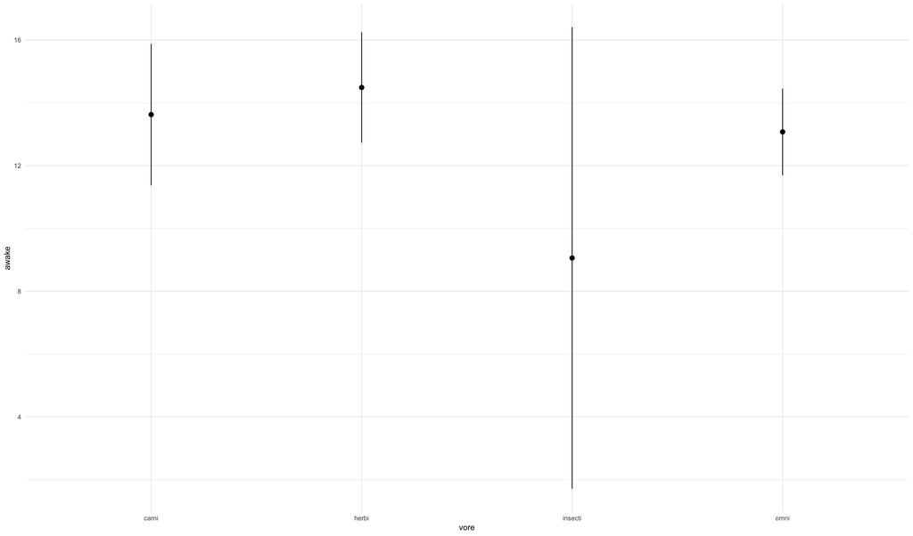

```r
msleep_nona <- filter(msleep, !is.na(vore))
ggplot(msleep_nona, aes(vore, awake)) +
  geom_confint()
```

## Model Fit

We will not discuss all of the output of the `reg_table` function in this course, but one other piece of information will come in handy: the Multiple R-squared. We define the residual of a model as the difference between the actual observed response minus the fitted mean. So, in this case we would have the following residuals:

$$\begin{align*}
\text{residual}_{\text{Cheetah}} &= \text{awake}_{\text{Cheetah}} - \text{mean}(\text{awake hours for all carnivores}) \\
\text{residual}_{\text{Owl monkey}} &= \text{awake}_{\text{Owl monkey}} - \text{mean}(\text{awake hours for all omnivores}) \\
\text{residual}_{\text{Mountain beaver}} &= \text{awake}_{\text{Mountain beaver}} - \text{mean}(\text{awake hours for all herbivores}) \\
\text{residual}_{\text{Cow}} &= \text{awake}_{\text{Cow}} - \text{mean}(\text{awake hours for all herbivores}) \\
&\vdots \\
\text{residual}_{\text{Red fox}} &= \text{awake}_{\text{Red fox}} - \text{mean}(\text{awake hours for all carnivores})
\end{align*}$$

Then, the multiple R-squared is given by:

$$\begin{align*}
R^2 &= 1 - \frac{Var(\text{all residuals})}{Var(\text{all response values})}
\end{align*}$$

This quantity will always be between 0 and 1, with values closer to 1 indicating that the model is describing a large proportion of the variation in the response variable. Notice that the R-squared value is always equal to 0 for a simple model with just a single mean.